# Text visualization

# Objectives

- Identify the basic workflow for conducting text analysis
- Descriptive text visualization
  - Wordclouds
  - N-gram viewers
- Geospatial visualization
- Network analysis

```r
library(tidyverse)
library(knitr)
library(broom)
library(stringr)
library(modelr)
library(forcats)
library(tidytext)
library(rtweet)
library(wordcloud)
library(scales)

options(digits = 3)
set.seed(1234)
theme_set(theme_minimal())
```

# Basic workflow for text analysis

- Obtain your text sources
- Extract documents and move into a corpus
- Transformation
- Extract features
- Perform analysis

## Obtain your text sources

Text data can come from lots of areas:

- Web sites
  - Twitter
- Databases
- PDF documents
- Digital scans of printed materials

The easier to convert your text data into digitally stored text, the cleaner your results and fewer transcription errors.

## Extract documents and move into a corpus

A **text corpus** is a large and structured set of texts. It typically stores the text as a [raw character string](http://r4ds.had.co.nz/strings.html) with meta data and details stored with the text.

## Transformation

Examples of typical transformations include:

- Tagging segments of speech for part-of-speech (nouns, verbs, adjectives, etc.) or entity recognition (person, place, company, etc.)
- Standard text processing - we want to remove extraneous information from the text and standardize it into a uniform format. This typically involves:
  - Converting to lower case
  - Removing punctuation
  - Removing numbers
  - Removing **stopwords** - common parts of speech that are not informative such as *a*, *an*, *be*, *of*, etc.
  - Removing domain-specific stopwords
  - Stemming - reduce words to their word stem
    - “Fishing”, “fished”, and “fisher” -> “fish”

## Extract features

Feature extraction involves converting the text string into some sort of quantifiable measures. The most common approach is the **bag-of-words model**, whereby each document is represented as a vector which counts the frequency of each term’s appearance in the document. You can combine all the vectors for each document together and you create a *term-document matrix*:

- Each row is a document
- Each column is a term
- Each cell represents the frequency of the term appearing in the document

However the bag-of-word model ignores **context**. You could randomly scramble the order of terms appearing in the document and still get the same term-document matrix.

## Perform analysis

At this point you now have data assembled and ready for analysis. There are several approaches you may take when analyzing text depending on your research question. Basic approaches include:

- Word frequency - counting the frequency of words in the text
- Collocation - words commonly appearing near each other
- Dictionary tagging - locating a specific set of words in the texts

More advanced methods include **document classification**, or assigning documents to different categories. This can be **supervised** (the potential categories are defined in advance of the modeling) or **unsupervised** (the potential categories are unknown prior to analysis). You might also conduct **corpora comparison**, or comparing the content of different groups of text. This is the approach used in plagiarism detecting software such as [Turn It In](http://turnitin.com/). Finally, you may attempt to detect clusters of document features, known as **topic modeling**.

# Descriptive text visualization

## Wordclouds

So far we’ve used basic plots from `ggplot2` to visualize our text data. However we could also use a **word cloud** to represent our text data. Also known as a **tag cloud**, word clouds visually represent text data by weighting the importance of each word, typically based on frequency in the text document. We can use the `wordcloud` package in R to generate these plots based on our tidied text data.

To draw the wordcloud, we need the data in tidy text format, so one-row-per-term. For example, here is a wordcloud of a set of tweets related to `#rstats`:

```r
library(wordcloud)

# get tweets
rt <- search_tweets(
  q = "#rstats",
  n = 3000,
  include_rts = FALSE
)
rt
```

```
## # A tibble: 2,689 x 42
##    status_id  created_at          user_id  screen_name text         source
##    <chr>      <dttm>              <chr>    <chr>       <chr>        <chr>
##  1 998959904… 2018-05-22 16:12:55 3967465… grssnbchr   Willst Du w… Tweet…
##  2 998959845… 2018-05-22 16:12:41 89191817 BigDataIns… "Big | Data… Paper…
##  3 998959486… 2018-05-22 16:11:16 21136238 rihender    Will exchan… Twitt…
##  4 998959214… 2018-05-22 16:10:11 3044686… thinkR_fr   #RStats — C… Hoots…
##  5 998957195… 2018-05-22 16:02:09 2335858… CRANberrie… CRAN update… CRANb…
##  6 998956655… 2018-05-22 16:00:01 2953443… RLangTip    List of R p… Tweet…
##  7 998955208… 2018-05-22 15:54:15 2859870… tripartio   Why multico… Twitt…
##  8 998955141… 2018-05-22 15:54:00 3909197… theothered… Mañana! Aco… Twitt…
##  9 998954783… 2018-05-22 15:52:34 8974458… lobrowR     "I have bee… Twitt…
## 10 998954416… 2018-05-22 15:51:07 3051574… __jsta      @SFWMD If y… Twitt…
## # ... with 2,679 more rows, and 36 more variables:
## #   reply_to_status_id <chr>, reply_to_user_id <chr>,
## #   reply_to_screen_name <chr>, is_quote <lgl>, is_retweet <lgl>,
## #   favorite_count <int>, retweet_count <int>, hashtags <list>,
## #   symbols <list>, urls_url <list>, urls_t.co <list>,
## #   urls_expanded_url <list>, media_url <list>, media_t.co <list>,
## #   media_expanded_url <list>, media_type <list>, ext_media_url <list>,
## #   ext_media_t.co <list>, ext_media_expanded_url <list>,
## #   ext_media_type <lgl>, mentions_user_id <list>,
## #   mentions_screen_name <list>, lang <chr>, quoted_status_id <chr>,
## #   quoted_text <chr>, retweet_status_id <chr>, retweet_text <chr>,
## #   place_url <chr>, place_name <chr>, place_full_name <chr>,
## #   place_type <chr>, country <chr>, country_code <chr>,
## #   geo_coords <list>, coords_coords <list>, bbox_coords <list>
```

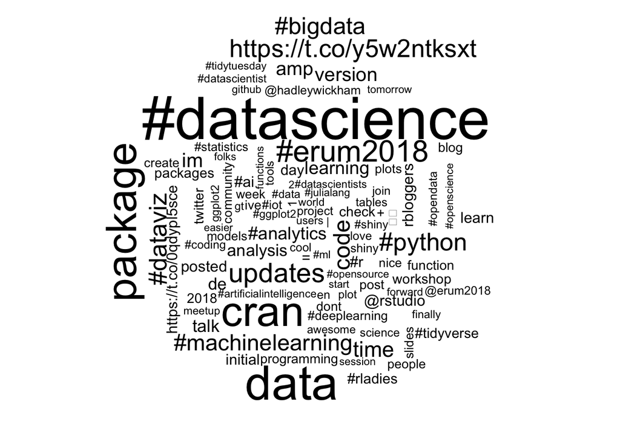

```r
# tokenize
rstats_token <- rt %>%
  unnest_tokens(word, text, token = "tweets") %>%
  filter(!word %in% stop_words$word)

# plot
rstats_token %>%
  count(word) %>%
  filter(word != "#rstats") %>%
  with(wordcloud(word, n, max.words = 100))
```

Or tweets by [Pope Francis](https://twitter.com/Pontifex):

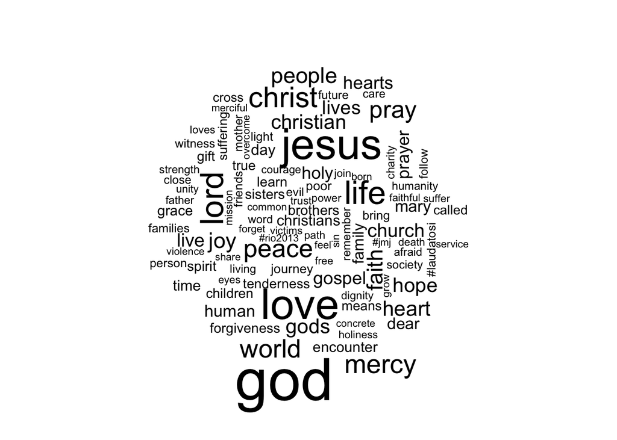

```r
# get tweets
pope <- get_timelines("Pontifex",
                      n = 3200,
                      include_rts = FALSE)

# tokenize
pope_token <- pope %>%
  unnest_tokens(word, text, token = "tweets") %>%
  filter(!word %in% stop_words$word)

# plot
pope_token %>%
  count(word) %>%
  with(wordcloud(word, n, max.words = 100))
```

We can even use wordclouds to compare words or tokens through the `comparison.cloud()` function. For instance, how do the tweets by Donald Trump compare to Pope Francis? In order to make this work, we need to convert our tidy data frame into a matrix first using the `acast()` function from `reshape2`, then use that for `comparison.cloud()`.

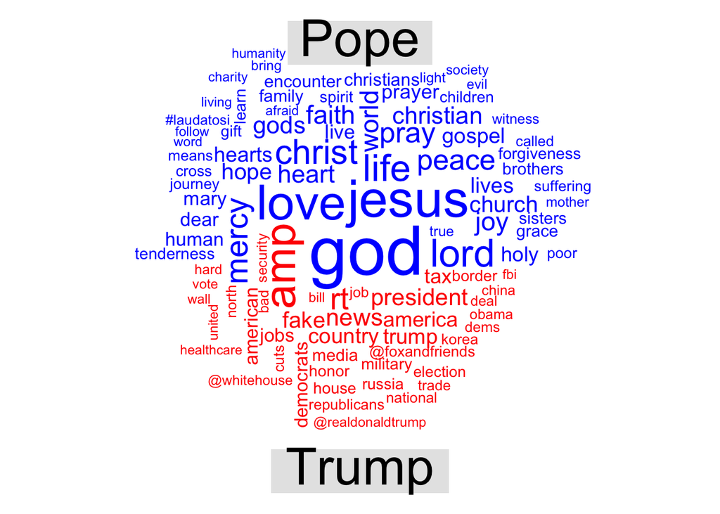

```r
library(reshape2)

# get fresh trump tweets
trump <- get_timelines("realdonaldtrump",
                      n = 3200,
                      include_rts = FALSE)

# tokenize
trump_token <- trump %>%
  unnest_tokens(word, text, token = "tweets") %>%
  filter(!word %in% stop_words$word)

bind_rows(Trump = trump_token, Pope = pope_token, .id = "person") %>%
  count(word, person) %>%
  acast(word ~ person, value.var = "n", fill = 0) %>%
  comparison.cloud(max.words = 100, colors = c("blue", "red"))
```

The size of a word’s text is in proportion to its frequency within its category (i.e. proportion of all Trump tweets or all pope tweets). We can use this visualization to see the most frequent words/hashtags by President Trump and Pope Francis, but the sizes of the words are not comparable across sentiments.

## N-gram viewers

An **n-gram** is a contiguous sequence of $n$ items from a given sequence of text or speech.

- n-gram of size 1 = unigram
- n-gram of size 2 = bigram
- n-gram of size 3 = trigram
- n-gram of size 4 = four-gram, etc.

This starts to incorporate context into our visualization. Rather than assuming all words/tokens are unique and independent from one another, n-grams of size 2 and up join together pairs or combinations of words in order to identify frequency within a document.

### Examples of n-gram viewers

- [Google Books Ngram Viewer](https://books.google.com/ngrams)
  - “Fuck”
  - “the Great War” vs. “the World War” vs. “World War I”
  - [“upward trend”](https://books.google.com/ngrams/graph?content=upward+trend&year_start=1850&year_end=2000&corpus=15&smoothing=3&share=&direct_url=t1%3B%2Cupward%20trend%3B%2Cc0)
  - “love” vs. “hope” vs. “faith” vs. “sex”
  - [“President”](https://books.google.com/ngrams/graph?content=President&year_start=1750&year_end=2000&corpus=15&smoothing=3&share=&direct_url=t1%3B%2CPresident%3B%2Cc0)
  - [“prime the pump”](https://books.google.com/ngrams/graph?content=prime+the+pump&year_start=1880&year_end=2000&corpus=15&smoothing=3&share=&direct_url=t1%3B%2Cprime%20the%20pump%3B%2Cc0)
  - “merry Christmas” vs. “happy holidays”
  - “telephone” vs. “telegram” vs. “television” vs. “radio” vs. “internet”
  - [Calendar of Meaningful Dates](https://www.xkcd.com/1140/)
- [How The Internet* Talks](https://projects.fivethirtyeight.com/reddit-ngram/?keyword=triggered.safe_space.sjw.snowflake&start=20071015&end=20161231&smoothing=10)

# Geospatial visualization with text

- Combines text data with geospatial visualization techniques
- Requires calculating statistics and frequency of terms for different regions to be plotted
- [Which Curse Words Are Popular In Your State? Find Out From These Maps.](http://www.huffingtonpost.com/entry/which-curse-words-are-popular-in-your-state_us_55a80662e4b04740a3df54b8)
- [Hate Map](http://users.humboldt.edu/mstephens/hate/hate_map.html)
- [Soda vs. Pop with Twitter](http://blog.echen.me/2012/07/06/soda-vs-pop-with-twitter/)

# Network analysis with text

- Use text features to identify edges between nodes in a network
- [How every #GameOfThrones episode has been discussed on Twitter](https://interactive.twitter.com/game-of-thrones/#?episode=1)

# Sentiment analysis

**Sentiment analysis** uses text analysis to estimate the attitude of a speaker or writer with respect to some topic or the overall polarity of the document. For example, the sentence

> I am happy

contains words and language typically associated with positive feelings and emotions. Therefore if someone tweeted “I am happy”, we could make an educated guess that the person is expressing positive feelings.

Obviously it would be difficult for us to create a complete dictionary that classifies words based on their emotional affect; fortunately other scholars have already done this for us. Some simply classify words and terms as positive or negative:

```r
get_sentiments("bing")
```

```
## # A tibble: 6,788 x 2
##    word        sentiment
##    <chr>       <chr>
##  1 2-faced     negative
##  2 2-faces     negative
##  3 a+          positive
##  4 abnormal    negative
##  5 abolish     negative
##  6 abominable  negative
##  7 abominably  negative
##  8 abominate   negative
##  9 abomination negative
## 10 abort       negative
## # ... with 6,778 more rows
```

Others rate them on a numeric scale:

```r
get_sentiments("afinn")
```

```
## # A tibble: 2,476 x 2
##    word       score
##    <chr>      <int>
##  1 abandon       -2
##  2 abandoned     -2
##  3 abandons      -2
##  4 abducted      -2
##  5 abduction     -2
##  6 abductions    -2
##  7 abhor         -3
##  8 abhorred      -3
##  9 abhorrent     -3
## 10 abhors        -3
## # ... with 2,466 more rows
```

Still others rate words based on specific sentiments

```r
get_sentiments("nrc")
```

```
## # A tibble: 13,901 x 2
##    word        sentiment
##    <chr>       <chr>
##  1 abacus      trust
##  2 abandon     fear
##  3 abandon     negative
##  4 abandon     sadness
##  5 abandoned   anger
##  6 abandoned   fear
##  7 abandoned   negative
##  8 abandoned   sadness
##  9 abandonment anger
## 10 abandonment fear
## # ... with 13,891 more rows
```

```r
get_sentiments("nrc") %>%
  count(sentiment)
```

```
## # A tibble: 10 x 2
##    sentiment        n
##    <chr>        <int>
##  1 anger         1247
##  2 anticipation   839
##  3 disgust       1058
##  4 fear          1476
##  5 joy            689
##  6 negative      3324
##  7 positive      2312
##  8 sadness       1191
##  9 surprise       534
## 10 trust         1231
```

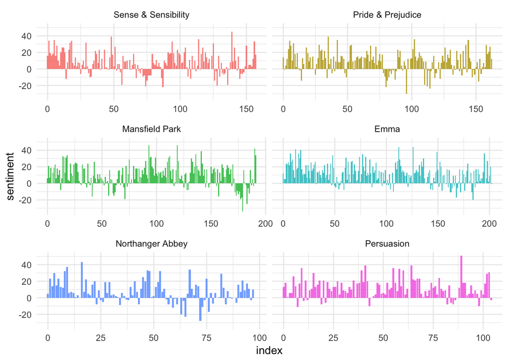

```r
library(janeaustenr)

tidy_books <- austen_books() %>%
  group_by(book) %>%
  mutate(linenumber = row_number(),
         chapter = cumsum(str_detect(text, regex("^chapter [\\divxlc]",
                                                 ignore_case = TRUE)))) %>%
  ungroup() %>%
  unnest_tokens(word, text)

janeaustensentiment <- tidy_books %>%
  inner_join(get_sentiments("bing")) %>%
  count(book, index = linenumber %/% 80, sentiment) %>%
  spread(sentiment, n, fill = 0) %>%
  mutate(sentiment = positive - negative)

ggplot(janeaustensentiment, aes(index, sentiment, fill = book)) +
        geom_bar(alpha = 0.8, stat = "identity", show.legend = FALSE) +
        facet_wrap(~book, ncol = 2, scales = "free_x")
```

Ignoring the specific code, this is a relatively simple operation. Once you have the text converted into a format suitable for analysis, tabulating and counting term frequency is not a complicated operation.

## Exploring content of Donald Trump’s Twitter timeline

- [Text analysis of Trump’s tweets confirms he writes only the (angrier) Android half](http://varianceexplained.org/r/trump-tweets/)
- [Trump’s Android and iPhone tweets, one year later](http://varianceexplained.org/r/trump-followup/)

[output not shown]

[output cut: 33 more lines]

[output not shown]